# Cardio Good Fitness Project

The data is about customers of the treadmill product(s) of a retail store called Cardio Good Fitness. It contains data related to customers who have purchased different product from Cardio Good Fitness. We are going to explore the dataset to come up with a customer profile (characteristics of a customer) of the different products. Perform univariate and multivariate analyses. Generate a set of insights and recommendations that will help the company in targeting new customers.

## Dataset Informations:

**CardioGoodFitness.csv:** It contains informations of customers of the treadmill product(s) of a retail store called Cardio Good Fitness. It contains the following columns: Product, Age, Gender, Education, Marital Status, Usage, Fitness, Income, Miles

## Objectives:

- Overview of the dataset shape, datatypes - Statistical summary and check for missing values
- Analysis of spread and distribution of every feature in the dataset.
- Analysis of interaction between features, in the dataset using univariate and multivariate analyses method
- Conclude with the key insights/observations

## Learning Outcomes:

`Learning about fundamentals of AIML`

### Domain

`marketing and manufacturing domain`

## Understanding the structure of the data

### 1. Import the necessary packages

```python
import pandas as pd
import numpy as np
import matplotlib.pyplot as plt
import seaborn as sns
```

### 2. Read the dataset

```python
# Reading dataset by using read_csv from pandas package

cgfitness = pd.read_csv("CardioGoodFitness.csv")
```

### 3. Understand the shape of the dataset

```python
# Analysing the data by looking at the first 5 rows of the data using Head function

cgfitness.head()
```

|  | Product | Age | Gender | Education | MaritalStatus | Usage | Fitness | Income | Miles |
| --- | --- | --- | --- | --- | --- | --- | --- | --- | --- |
| 0 | TM195 | 18 | Male | 14 | Single | 3 | 4 | 29562 | 112 |
| 1 | TM195 | 19 | Male | 15 | Single | 2 | 3 | 31836 | 75 |
| 2 | TM195 | 19 | Female | 14 | Partnered | 4 | 3 | 30699 | 66 |
| 3 | TM195 | 19 | Male | 12 | Single | 3 | 3 | 32973 | 85 |
| 4 | TM195 | 20 | Male | 13 | Partnered | 4 | 2 | 35247 | 47 |

```python
# Analysing the data by looking at the last 5 rows of the data using tail function

cgfitness.tail()
```

|  | Product | Age | Gender | Education | MaritalStatus | Usage | Fitness | Income | Miles |
| --- | --- | --- | --- | --- | --- | --- | --- | --- | --- |
| 175 | TM798 | 40 | Male | 21 | Single | 6 | 5 | 83416 | 200 |
| 176 | TM798 | 42 | Male | 18 | Single | 5 | 4 | 89641 | 200 |
| 177 | TM798 | 45 | Male | 16 | Single | 5 | 5 | 90886 | 160 |
| 178 | TM798 | 47 | Male | 18 | Partnered | 4 | 5 | 104581 | 120 |
| 179 | TM798 | 48 | Male | 18 | Partnered | 4 | 5 | 95508 | 180 |

```python
# Finding the shape of the dataset using dataframe.shape

cgfitness.shape
```

```
(180, 9)
```

**Observation:** There are 180 rows and 9 columns in the cgfitness dataset

### 4. Check the data types of the columns for the dataset.

```python
# We use dataframe.dtypes to get the data types of each column
fitness.dtypes
```

```
Product          object
Age               int64
Gender           object
Education         int64
MaritalStatus    object
Usage             int64
Fitness           int64
Income            int64
Miles             int64
dtype: object
```

**Observation:**

- Age, Education, Usage, Fitness, Income and Miles columns are of integer data types.
- Product, Gender and MaritalStatus columns are of string data type.

### 5. Check the statistical summary for the dataset.

```python
# We use dataframe.describe to get the statistical summary of each column
fitness.describe()
```

|  | Age | Education | Usage | Fitness | Income | Miles |
| --- | --- | --- | --- | --- | --- | --- |
| count | 180.000000 | 180.000000 | 180.000000 | 180.000000 | 180.000000 | 180.000000 |
| mean | 28.788889 | 15.572222 | 3.455556 | 3.311111 | 53719.577778 | 103.194444 |
| std | 6.943498 | 1.617055 | 1.084797 | 0.958869 | 16506.684226 | 51.863605 |
| min | 18.000000 | 12.000000 | 2.000000 | 1.000000 | 29562.000000 | 21.000000 |
| 25% | 24.000000 | 14.000000 | 3.000000 | 3.000000 | 44058.750000 | 66.000000 |
| 50% | 26.000000 | 16.000000 | 3.000000 | 3.000000 | 50596.500000 | 94.000000 |
| 75% | 33.000000 | 16.000000 | 4.000000 | 4.000000 | 58668.000000 | 114.750000 |
| max | 50.000000 | 21.000000 | 7.000000 | 5.000000 | 104581.000000 | 360.000000 |

**Observation:**

- The Mean, Median and Standard Deviation of Ages are 28.78, 26 & 6.94 respectively
- The Mean, Median and Standard Deviation of Educations are 15.57, 16 & 1.617 respectively
- The Mean, Median and Standard Deviation of Usage are 3.45, 3 & 1.08 respectively
- The Mean, Median and Standard Deviation of Fitness are 3.31, 3 & 0.95 respectively
- The Mean, Median and Standard Deviation of Income are 53719.57, 50596.5 & 16506.68 respectively
- The Mean, Median and Standard Deviation of Miles are 103.19, 94 & 51.86 respectively

### 6. Check for missing values

```python
# We use dataframe.isnull().sum() to get the missing values and sum of the total missing values of each column
cgfitness.isnull().sum()
```

```
Product          0
Age              0
Gender           0
Education        0
MaritalStatus    0
Usage            0
Fitness          0
Income           0
Miles            0
dtype: int64
```

**Observation:** There are no missing values in the fitness dataset

## Data Visualization - Univariate Data Analysis

Univariate analysis refer to the analysis of a single variable. The main purpose of univariate analysis is to summarize and find patterns in the data. The key point is that there is only one variable involved in the analysis.

Let us take the fitness dataset and work on that for the univariate analysis.

### Analysis of spread and distribution of every feature in the dataset

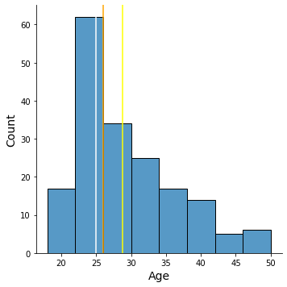

```python
# plots a histogram plt using the seaborn package for Age column.
# Using displot since distplot going to be decommissioned in the future

sns.displot(cgfitness,
            x = "Age",
            bins=8,
            height=5)
plt.xlabel("Age", size=14)
plt.ylabel("Count", size=14)
plt.axvline(x=cgfitness.Age.mean(),
            color='yellow')
plt.axvline(x=cgfitness.Age.median(),
            color='orange')
plt.axvline(x=cgfitness.Age.mode()[0],
            color='white')
```

**Observations:**

Now we have an idea of how the data is distributed for age.

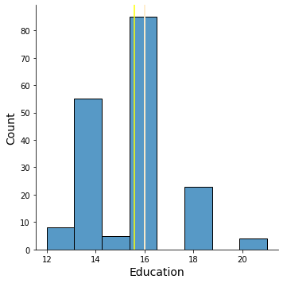

```python
# plots a histogram plt using the seaborn package for Education column.

sns.displot(cgfitness,
            x = "Education",
            bins=8,
            height=5)
plt.xlabel("Education", size=14)
plt.ylabel("Count", size=14)
plt.axvline(x=cgfitness.Education.mean(),
            color='yellow')
plt.axvline(x=cgfitness.Education.median(),
            color='orange')
plt.axvline(x=cgfitness.Education.mode()[0],
            color='white')
```

**Observations:**

- In this case we are analysing Education column. We can safely say based on visual observation that most of the customers have 16 years of education
- In the above histograms we can see that a bulk of the observations lie in the 2nd and 4th classes. The rest of the classes contain only a very few observations.
- From the above figure we can see that mean is represented by the yellow line, the mode by the white line and The median is represented by the orange line.
- We can see from the above figure that the mode and the median are very close to each other and the mean is lesser than both.

Now we have an idea of how the data is distributed for Education.

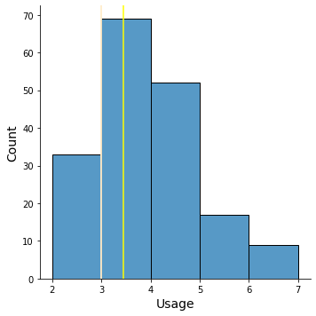

```python
# plots a histogram plt using the seaborn package for Usage column.

sns.displot(cgfitness,
            x = "Usage",
            bins=5,
            height=5)
plt.xlabel("Usage", size=14)
plt.ylabel("Count", size=14)
plt.axvline(x=cgfitness.Usage.mean(),
            color='yellow')
plt.axvline(x=cgfitness.Usage.median(),
            color='orange')
plt.axvline(x=cgfitness.Usage.mode()[0],
            color='white')
```

##### **Observations:**

Now we have an idea of how the data is distributed for Usage.

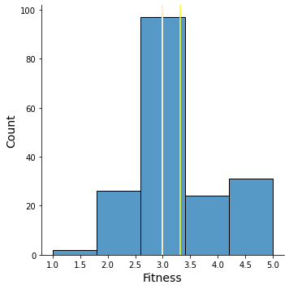

```python
# plots a histogram plt using the seaborn package for Fitness column.

sns.displot(cgfitness,
            x = "Fitness",
            bins=5,
            height=5)
plt.xlabel("Fitness", size=14)
plt.ylabel("Count", size=14)
plt.axvline(x=cgfitness.Fitness.mean(),
            color='yellow')
plt.axvline(x=cgfitness.Fitness.median(),
            color='orange')
plt.axvline(x=cgfitness.Fitness.mode()[0],
            color='white')
```

##### **Observations:**

- In this case we are analysing Fitness column. We can safely say based on visual observation that most of the count present on the data are 3 rated and other contains very few observations.
- From the above figure we can see that mean is represented by the yellow line, the mode by the white line and The median is represented by the orange line.
- We can see from the above figure that the mode and the median are very close to each other and the mean is higher than both.

Now we have an idea of how the data is distributed for Fitness.

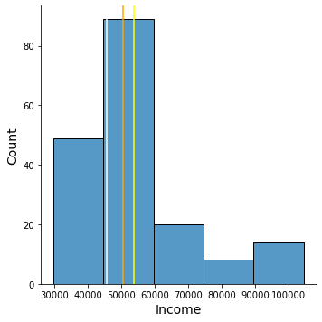

```python
# plots a histogram plt using the seaborn package for Income column.

sns.displot(cgfitness,
            x = "Income",
            bins=5,
            height=5)
plt.xlabel("Income", size=14)
plt.ylabel("Count", size=14)
plt.axvline(x=cgfitness.Income.mean(),
            color='yellow')
plt.axvline(x=cgfitness.Income.median(),
            color='orange')
plt.axvline(x=cgfitness.Income.mode()[0],
            color='white')
```

##### **Observations:**

Now we have an idea of how the data is distributed for Income.

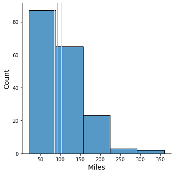

```python
# plots a histogram plt using the seaborn package for Miles column.

sns.displot(cgfitness,
            x = "Miles",
            bins=5,
            height=5)
plt.xlabel("Miles", size=14)
plt.ylabel("Count", size=14)
plt.axvline(x=cgfitness.Miles.mean(),
            color='yellow')
plt.axvline(x=cgfitness.Miles.median(),
            color='orange')
plt.axvline(x=cgfitness.Miles.mode()[0],
            color='white')
```

##### **Observations:**

Now we have an idea of how the data is distributed for Miles.

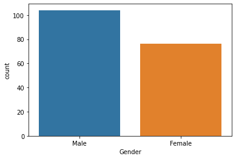

```python
# Based on Gender column who is buying more treadmill( Male or Female )

sns.countplot(x="Gender", data=cgfitness, palette="tab10")
```

**Observation:** We can safely say that Male cutomers are more than Female cutomers.

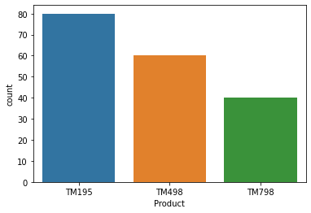

```python
# Based on Product which treadmill model is most sold

sns.countplot(x="Product", data=cgfitness, palette="tab10")
```

**Observation:** We can safely say that TM195 treadmill model is most sold model.

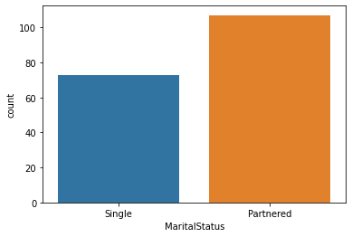

```python
# Based on MaritalStatus who is buying more treadmill(Partnered or Single)

sns.countplot(x="MaritalStatus", data=cgfitness, palette="tab10")
```

**Observation:** We can safely say that customers who are Partnered are buying more treadmill.